# 项目1：个股和指数的回归分析练习

- 1.获取个股及指数数据
- 2.数据处理与描述性统计
- 3.线性回归拟合

## 1.获取个股及指数数据

```python
#加载和命名各个包
%matplotlib inline
import matplotlib.pyplot as plt
import numpy as np
import pandas as pd
import pandas.io.data as web
import seaborn as sns
```

```python
#从雅虎财经获取2015年上证综合指数数据sse和万达院线股票价格数据wanda
sse=web.get_data_yahoo('000001.SS','2015-01-01','2015-12-31')
wanda=web.get_data_yahoo('002739.SZ','2015-01-01','2015-12-31')
```

## 2.数据处理与描述性统计

```python
#查看2015年万达院线股票价格数据
wanda.tail()
```

| Date | Open | High | Low | Close | Volume | Adj Close |
| --- | --- | --- | --- | --- | --- | --- |
| 2015-12-25 | 128.90 | 128.90 | 128.90 | 128.90 | 0 | 128.90 |
| 2015-12-28 | 127.55 | 131.00 | 124.61 | 126.80 | 10230800 | 126.80 |
| 2015-12-29 | 126.89 | 127.48 | 122.56 | 124.42 | 7832900 | 124.42 |
| 2015-12-30 | 124.20 | 124.40 | 120.80 | 121.51 | 7605900 | 121.51 |
| 2015-12-31 | 120.68 | 123.86 | 120.00 | 120.00 | 6738000 | 120.00 |

- 可以看到，股票价格数据有每日的开盘价、收盘价、最高价、最低价、成交量以及调整后的收盘价。

```python
#只选取每日调整后的收盘价做分析
sse1=sse['Adj Close']
wanda1=wanda['Adj Close']
sse1.head()
```

```
Date
2015-01-05    3350.52
2015-01-06    3351.45
2015-01-07    3373.95
2015-01-08    3293.46
2015-01-09    3285.41
Name: Adj Close, dtype: float64
```

### 数据处理

```python
df=pd.DataFrame([wanda1,sse1]).T     #将个股wanda和综指sse两组数据整合到一个数据框，并转置
df.columns=['wanda','sse']                    #重命名列
df1=df[df['wanda'].isnull()==False]
df2=df1[df['sse'].isnull()==False]         #这两行用来过滤缺失值，也可用函数df.dropna()
```

### 展示处理后的数据

```python
df2.describe()
```

|  | wanda | sse |
| --- | --- | --- |
| count | 220.000000 | 220.000000 |
| mean | 86.420159 | 3766.838136 |
| std | 29.250713 | 541.493131 |
| min | 15.270000 | 2927.290000 |
| 25% | 63.655500 | 3342.022500 |
| 50% | 91.237500 | 3635.820000 |
| 75% | 107.090000 | 4074.222500 |
| max | 130.540000 | 5166.350000 |

```python
df2.tail()
```

| Date | wanda | sse |
| --- | --- | --- |
| 2015-12-24 | 128.90 | 3612.49 |
| 2015-12-25 | 128.90 | 3627.91 |
| 2015-12-28 | 126.80 | 3533.78 |
| 2015-12-29 | 124.42 | 3563.74 |
| 2015-12-31 | 120.00 | 3539.18 |

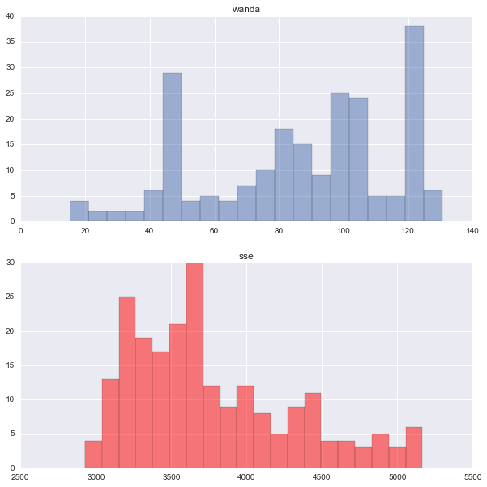

```python
#画wanda和sse的直方图
plt.figure(figsize=(10,10))
ax1 = plt.subplot(211)
ax2 = plt.subplot(212)
plt.sca(ax1)
plt.hist(df2.wanda,bins=20,alpha=0.5)
plt.title('wanda')
plt.sca(ax2)
plt.hist(df2.sse,bins=20,color='r',alpha=0.5)
plt.title('sse')
plt.show()
```

```python
#均值一致化处理
df3=df2
df3.sse=df3.sse/(np.mean(df3.sse)/np.mean(df3.wanda))
df3.head()
```

| Date | wanda | sse |
| --- | --- | --- |
| 2015-01-22 | 15.270 | 76.704112 |
| 2015-01-23 | 16.795 | 76.897287 |
| 2015-01-26 | 18.474 | 77.618136 |
| 2015-01-27 | 20.321 | 76.924818 |
| 2015-01-28 | 22.353 | 75.841479 |

### 画出走势

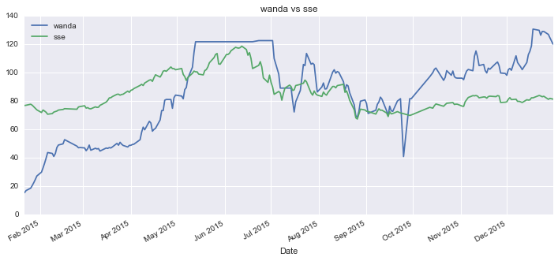

```python
df3.plot(figsize=(12,5),title='wanda vs sse')
plt.show()
```

```python
print df3.sse.std()
print df3.wanda.std()
```

```
12.4231307137
29.2507127436
```

- 走势图表明，总体上看，wanda和sse一定程度上具备相同的趋势。但看上去see更加平稳一点，这容易理解，因为sse(大盘)可以看做是多只股票的加权平均，理论上更加稳健，sse和wanda标准差的比较也说明了这一点。

## 3.线性回归拟合

```python
#加载回归分析需要的包
import statsmodels.formula.api as sm
```

### 建立回归

```python
df2=df1[df['sse'].isnull()==False]          #使用均值未一致化前的数据df2
model=sm.OLS(df2.wanda,df2.sse)      #用最小二乘法OLS建立回归模型
result=model.fit()
result.summary()                                 #输出回归模型的总结
```

OLS Regression Results

| Dep. Variable: | wanda | R-squared: | 0.925 |
| --- | --- | --- | --- |
| Model: | OLS | Adj. R-squared: | 0.925 |
| Method: | Least Squares | F-statistic: | 2714. |
| Date: | Fri, 18 Mar 2016 | Prob (F-statistic): | 2.31e-125 |
| Time: | 23:35:41 | Log-Likelihood: | -1019.7 |
| No. Observations: | 220 | AIC: | 2041. |
| Df Residuals: | 219 | BIC: | 2045. |
| Df Model: | 1 |  |  |
| Covariance Type: | nonrobust |  |  |

|  | coef | std err | t | P>\|t\| | [95.0% Conf. Int.] |
| --- | --- | --- | --- | --- | --- |
| sse | 0.0231 | 0.000 | 52.092 | 0.000 | 0.022 0.024 |

| Omnibus: | 21.084 | Durbin-Watson: | 0.049 |
| --- | --- | --- | --- |
| Prob(Omnibus): | 0.000 | Jarque-Bera (JB): | 12.953 |
| Skew: | -0.450 | Prob(JB): | 0.00154 |
| Kurtosis: | 2.224 | Cond. No. | 1.00 |

```python
print result.params                                        #输出回归方程系数
print result.ssr                                               #输出残差平方和
```

```
sse    0.023058
dtype: float64
136694.311242
```

### 画散点图和回归线

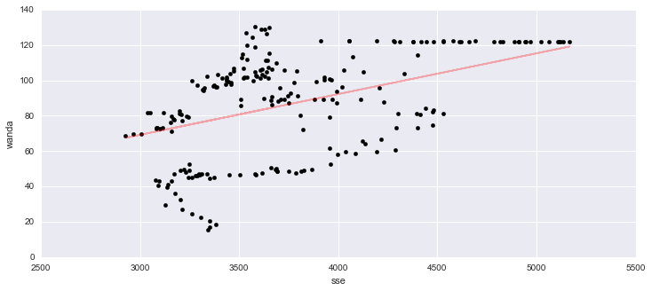

```python
plt.figure(figsize=(12,5))
plt.scatter(df2.sse,df2.wanda,color='black')
plt.plot( df2.sse, result.predict( df2.sse ), color='r',alpha=0.3)
plt.xlabel('sse')
plt.ylabel('wanda')
#plt.xlim(0, 5500)  如果运行该行代码，则定义x轴范围从0开始，可以看到截距为0
plt.show()
```

- 散点图中，横轴是上证指数数据sse，纵轴是wanda股价数据，注意横轴是2500开始，如果横轴从0开始，会看到截距项确实为0。

### 附：线性回归（广义）的另一种实现方法

> from sklearn import linear_model  
> x1 = np.array(df2.sse).reshape((220,1))  
> y1 = np.array(df2.wanda)  
> lm=linear_model.LinearRegression()  
> lm.fit(x1,y1)

> *#x1要将数据强制转换成220行1列，十分关键*  
> *#广义线性回归参数估计方法并不是最小二乘法，所以最后拟合出来的回归方程其截距和系数与OLS会有差异*

# 项目2：Titanic项目数据分析报告

- 1.数据获取
- 2.数据整理
- 3.逃生预测
  - 3.1随机森林
  - 3.2逻辑回归

## 1.数据获取

```python
#加载分析需要的包
import csv
import pylab as pl
from sklearn.ensemble import RandomForestClassifier     #随机森林算法
from sklearn import cross_validation                                #交叉验证
from sklearn.cross_validation import cross_val_score
import statsmodels.api as sm                                           #逻辑回归
```

```python
#合并训练数据和测试数据集
train_df = pd.read_csv('train.csv', header=0)
test_df  = pd.read_csv('test.csv',  header=0)
data = pd.concat([train_df, test_df])
data = data.reindex_axis(train_df.columns, axis=1)
print np.shape(data)
data.head()
```

```
(1309, 12)
```

|  | PassengerId | Survived | Pclass | Name | Sex | Age | SibSp | Parch | Ticket | Fare | Cabin | Embarked |
| --- | --- | --- | --- | --- | --- | --- | --- | --- | --- | --- | --- | --- |
| 0 | 1 | 0 | 3 | Braund, Mr. Owen Harris | male | 22 | 1 | 0 | A/5 21171 | 7.2500 | NaN | S |
| 1 | 2 | 1 | 1 | Cumings, Mrs. John Bradley (Florence Briggs Th... | female | 38 | 1 | 0 | PC 17599 | 71.2833 | C85 | C |
| 2 | 3 | 1 | 3 | Heikkinen, Miss. Laina | female | 26 | 0 | 0 | STON/O2. 3101282 | 7.9250 | NaN | S |
| 3 | 4 | 1 | 1 | Futrelle, Mrs. Jacques Heath (Lily May Peel) | female | 35 | 1 | 0 | 113803 | 53.1000 | C123 | S |
| 4 | 5 | 0 | 3 | Allen, Mr. William Henry | male | 35 | 0 | 0 | 373450 | 8.0500 | NaN | S |

- 由于训练数据和测试数据都含有缺失值，因此合并成一个数据方便统一处理。合并成的数据命名为data，一共有1309行12列，并按照训练数据的列名排序（如第一列为PassengerId，第二列为Survived）。
- 变量解释

| 变量名 | 变量解释 |
| --- | --- |
| PassengerId | 乘客编号 |
| Survived | 存活与否 |
| Pclass | 船舱等级 |
| Name | 姓名 |
| Sex | 性别 |
| Age | 年龄 |
| SibSp | 亲戚和配偶在船数量 |
| Parch | 父母孩子的在船数量 |
| Ticket | 票编号 |
| Fare | 票价 |
| Cabin | 客舱位置 |
| Embarked | 上船的港口编号 |

```python
#数据信息
print data.info()
data.describe()
```

```
<class 'pandas.core.frame.DataFrame'>
Int64Index: 1309 entries, 0 to 417
Data columns (total 12 columns):
PassengerId    1309 non-null int64
Survived       891 non-null float64
Pclass         1309 non-null int64
Name           1309 non-null object
Sex            1309 non-null object
Age            1046 non-null float64
SibSp          1309 non-null int64
Parch          1309 non-null int64
Ticket         1309 non-null object
Fare           1308 non-null float64
Cabin          295 non-null object
Embarked       1307 non-null object
dtypes: float64(3), int64(4), object(5)
memory usage: 132.9+ KB
None
```

|  | PassengerId | Survived | Pclass | Age | SibSp | Parch | Fare |
| --- | --- | --- | --- | --- | --- | --- | --- |
| count | 1309.000000 | 891.000000 | 1309.000000 | 1046.000000 | 1309.000000 | 1309.000000 | 1308.000000 |
| mean | 655.000000 | 0.383838 | 2.294882 | 29.881138 | 0.498854 | 0.385027 | 33.295479 |
| std | 378.020061 | 0.486592 | 0.837836 | 14.413493 | 1.041658 | 0.865560 | 51.758668 |
| min | 1.000000 | 0.000000 | 1.000000 | 0.170000 | 0.000000 | 0.000000 | 0.000000 |
| 25% | 328.000000 | 0.000000 | 2.000000 | 21.000000 | 0.000000 | 0.000000 | 7.895800 |
| 50% | 655.000000 | 0.000000 | 3.000000 | 28.000000 | 0.000000 | 0.000000 | 14.454200 |
| 75% | 982.000000 | 1.000000 | 3.000000 | 39.000000 | 1.000000 | 0.000000 | 31.275000 |
| max | 1309.000000 | 1.000000 | 3.000000 | 80.000000 | 8.000000 | 9.000000 | 512.329200 |

## 2.数据整理

- 从上面可以看到，data总共有1309行数据，而Cabin（客舱位置）这一列只有295个非缺失值，不适合用缺失值插补的方法，因此应删除该列。其他缺失值（Age缺失263个、Fare缺失1个、Embarked缺失2个）根据特点选择用中位数、均值或众数进行插补。

### 填补缺失值

```python
data = data.drop('Cabin', axis=1)                                       #缺失值太多，剔除Cabin变量
data['Age'][data['Age'].isnull()] = data['Age'].median()        #年龄缺失值用中位数插补
data['Fare'][data['Fare'].isnull()] = data['Fare'].mean()         #票价缺失值用均值插补
data['Embarked'][data['Embarked'].isnull()] = data['Embarked'].mode().values    #上船港口编号缺失值用众数插补
```

```python
data['Sex'] = pd.factorize(data['Sex'])[0]                           #将性别、上船港口转换为因子
data['Embarked'] = pd.factorize(data['Embarked'])[0]
data = data.drop('Name', axis=1)                                     #简便起见，删除姓名和船票编号
data = data.drop('Ticket', axis=1)
```

## 3.逃生预测

```python
data1=data[:]
data1.head()
```

|  | PassengerId | Survived | Pclass | Sex | Age | SibSp | Parch | Fare | Embarked |
| --- | --- | --- | --- | --- | --- | --- | --- | --- | --- |
| 0 | 1 | 0 | 3 | 0 | 22 | 1 | 0 | 7.2500 | 0 |
| 1 | 2 | 1 | 1 | 1 | 38 | 1 | 0 | 71.2833 | 1 |
| 2 | 3 | 1 | 3 | 1 | 26 | 0 | 0 | 7.9250 | 0 |
| 3 | 4 | 1 | 1 | 1 | 35 | 1 | 0 | 53.1000 | 0 |
| 4 | 5 | 0 | 3 | 0 | 35 | 0 | 0 | 8.0500 | 0 |

```python
known_survived = data1[data1['Survived'].notnull()].values            #已知的用来训练模型
unknown_survived = data1[data1['Survived'].isnull()].values          #未知的用来预测
Y = known_survived[:, 1]                                                                  #将Survived作为因变量
X = known_survived[:, 2:]                                                                #将其他变量作为自变量
```

## 3.1随机森林

### 建立模型

```python
forest= RandomForestClassifier(n_estimators=100)
fit1=forest.fit(X,Y)
```

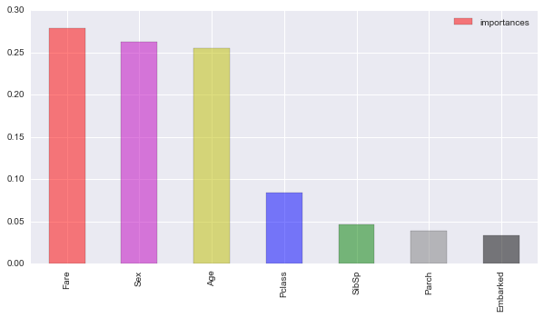

```python
#画变量重要性图
imp=pd.DataFrame([fit1.feature_importances_])
imp.columns=data1.columns[2:]
imp1=imp.T.sort(columns=0,ascending=False)
imp1.columns=['importances']
imp1.plot(kind='bar',figsize=(10,5),color=['r','m','y','b','g','gray','black'],alpha=0.5)
plt.show()
```

```python
imp1
```

|  | importances |
| --- | --- |
| Fare | 0.275476 |
| Sex | 0.269328 |
| Age | 0.253884 |
| Pclass | 0.083822 |
| SibSp | 0.047141 |
| Parch | 0.037020 |
| Embarked | 0.033329 |

- 从随机森林拟合出的变量重要性图可以看出，影响一个乘客能否成功逃生的三个最主要因素是：Fare船票价格（票价越高可能表示社会地位更高，可能在逃生时更有优先权）、Sex性别（女士优先）、Age年龄（青壮年可能更具备逃生获救的能力）。

### 交叉验证

```python
#输出交叉验证得分及均值
print cross_val_score(fit1, X, Y)
cross_val_score(fit1,X,Y).mean()
```

```
[ 0.78114478  0.8013468   0.79124579]
```

```
0.79573512906846233
```

### 模型预测

```python
#随机森林预测
pred1 = fit1.predict(unknown_survived[:, 2:]).astype(int)
print pd.value_counts(pred1)
```

```
0    265
1    153
dtype: int64
```

- 预测结果为265名乘客死亡，153名乘客存活。

```python
#展示预测结果
result1=data1[data1['Survived'].isnull()][['PassengerId','Survived']]
result1['Survived']=pred1
result1.tail(10)
```

|  | PassengerId | Survived |
| --- | --- | --- |
| 408 | 1300 | 1 |
| 409 | 1301 | 1 |
| 410 | 1302 | 1 |
| 411 | 1303 | 1 |
| 412 | 1304 | 0 |
| 413 | 1305 | 0 |
| 414 | 1306 | 1 |
| 415 | 1307 | 0 |
| 416 | 1308 | 0 |
| 417 | 1309 | 1 |

- 训练集有891位乘客，从第892位乘客开始一直到第1309位即测试集（待预测）的乘客。上表展示了随机森林预测结果的后十行。

## 3.2逻辑斯蒂回归

### 建立模型

```python
logit=sm.Logit(Y,X)
fit2=logit.fit()
```

```
Optimization terminated successfully.
         Current function value: 0.453001
         Iterations 6
```

### 回归方程

```python
#输出模型结果
fit2.summary()
```

Logit Regression Results

| Dep. Variable: | y | No. Observations: | 891 |
| --- | --- | --- | --- |
| Model: | Logit | Df Residuals: | 884 |
| Method: | MLE | Df Model: | 6 |
| Date: | Fri, 18 Mar 2016 | Pseudo R-squ.: | 0.3197 |
| Time: | 17:19:39 | Log-Likelihood: | -403.62 |
| converged: | True | LL-Null: | -593.33 |
|  |  | LLR p-value: | 7.458e-79 |

|  | coef | std err | z | P>\|z\| | [95.0% Conf. Int.] |
| --- | --- | --- | --- | --- | --- |
| x1 | -0.5777 | 0.076 | -7.649 | 0.000 | -0.726 -0.430 |
| x2 | 2.7223 | 0.192 | 14.158 | 0.000 | 2.345 3.099 |
| x3 | -0.0151 | 0.005 | -2.790 | 0.005 | -0.026 -0.005 |
| x4 | -0.2956 | 0.103 | -2.875 | 0.004 | -0.497 -0.094 |
| x5 | -0.1184 | 0.115 | -1.030 | 0.303 | -0.344 0.107 |
| x6 | 0.0083 | 0.003 | 3.185 | 0.001 | 0.003 0.013 |
| x7 | 0.2312 | 0.139 | 1.658 | 0.097 | -0.042 0.505 |

\begin{eqnarray*} Y&=&ln（\frac{P_Survived}{1-P_Survived}）\ &=&-0.58*Pclass+2.72*Sex-0.015*Age-0.296*SibSp-0.12*Parch+0.01*Fare+0.23*Embarked \end{eqnarray*}

### 模型预测

```python
pred2 = fit2.predict(unknown_survived[:, 2:])
print np.shape(pred2)
pred2[0:10]
```

```
(418L,)
```

```
array([ 0.15083712,  0.51000534,  0.17489587,  0.11204309,  0.5851872 ,
        0.13371222,  0.74282587,  0.15157357,  0.73260008,  0.08004106])
```

- 预测完成后，pred2 的值是介于 [0, 1] 间的概率值，需要转换成0/1。比如，我们可以假设概率大于0.5认为是逃生成功（Survived=1）。

```python
pred2[pred2>0.5]=1
pred2[pred2<=0.5]=0
pred2=pred2.astype(int)
print pd.value_counts(pred2)
```

```
0    263
1    155
dtype: int64
```

- 作出上述假设后，预测结果为263名乘客死亡，155名乘客存活。该结果总数上与随机森林模型的预测结果相差无几。

```python
#展示预测结果
result2=data1[data1['Survived'].isnull()][['PassengerId','Survived']]
result2['Survived']=pred2
result2.tail(10)
```

|  | PassengerId | Survived |
| --- | --- | --- |
| 408 | 1300 | 1 |
| 409 | 1301 | 1 |
| 410 | 1302 | 1 |
| 411 | 1303 | 1 |
| 412 | 1304 | 1 |
| 413 | 1305 | 0 |
| 414 | 1306 | 1 |
| 415 | 1307 | 0 |
| 416 | 1308 | 0 |
| 417 | 1309 | 0 |

### 简单评估

```python
#画混淆矩阵
Y1=fit2.predict(X)
Y1[Y1>0.5]=1
Y1[Y1<=0.5]=0
tab=pd.DataFrame([Y,Y1]).T
tab.columns=['Real','Predict']
crosstab=pd.crosstab(tab['Real'],tab['Predict'])
crosstab.columns=[0,1]
crosstab.columns.names=['Predict']
crosstab
```

| Predict Real | 0 | 1 |
| --- | --- | --- |
| 0 | 477 | 72 |
| 1 | 109 | 233 |

```python
#计算正确率
(crosstab[0][0]+crosstab[1][1]+0.01)/(sum(crosstab[0])+sum(crosstab[1]))
```

```
0.79686868686868684
```

- 混淆矩阵对角线表示模型正确预测的人数，计算对角线之和除以总人数之和即为逻辑回归模型的准确度，结果是0.797。